# Plotting Geospatial Data

Emilio Luz-Ricca

# 1 Bringing in the Data and Basic Plotting

For this exercise, I decided to use Swaziland (now called Eswatini). I downloaded the geometry data as outlined in the instructions and brought in the data using the `read_sf()` function from the `sf` library.

The first plot that I made simply includes the international boundary and first level administrative boundaries, using the `geom_sf()` and `goem_sf_text()` functions from `ggplot`.

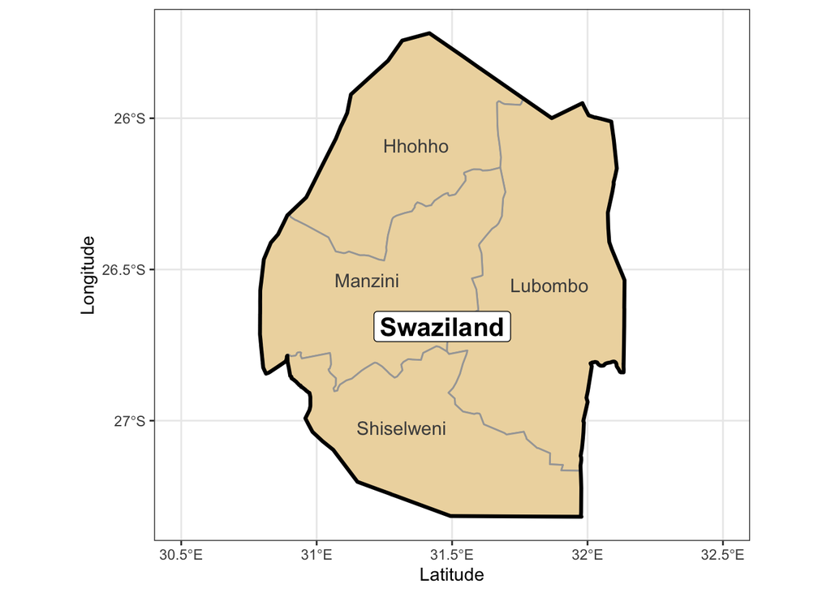

This is a nice plot, but is a bit basic on it’s own. To convey more information, I added the second level administrative boundaries.

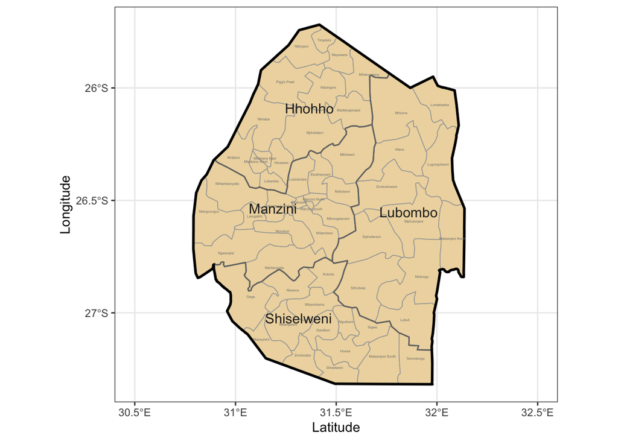

Bringing in second level administrative boundaries clutters up the plot a bit, but it’s still legible. To ensure that smaller features were less prominent, I decreased the `size` argument and moved along a greyscale for `color` in the `geom_sf_text()` and `geom_sf()` functions. This makes the plot much more readable.

# 2 Stretch Goals

In this section, I include the results from a few of the stretch goals in the first part of this exercise (titled *Individual Stretch Goal 2* and *Individual Stretch Goal 3*).

## 2.1 Looking at the Most Populous Region

After a little searching, I learned that Eswatini is divided into four **regions** (Hhohho, Lubombo, Manzini, and Shiselweni) and each region is further divided into many **tinkhundla** (their second level of administrative subdivision). For instance, the region Hhohho is split into the tinkhundla Hhukwini, Lobamba, Madlangempisi, Mayiwane, Mbabane East, Mbabane West, Mhlangatane, Motjane, Mphalaleni, Ndzingeni, Nkhaba, Ntfonjeni, Pigg’s Peak, and Timpisini.

The most populous region in Eswatini is Manzini, which is comprised of 16 tinkhundla. Here’s a plot of Manzini on it’s own.

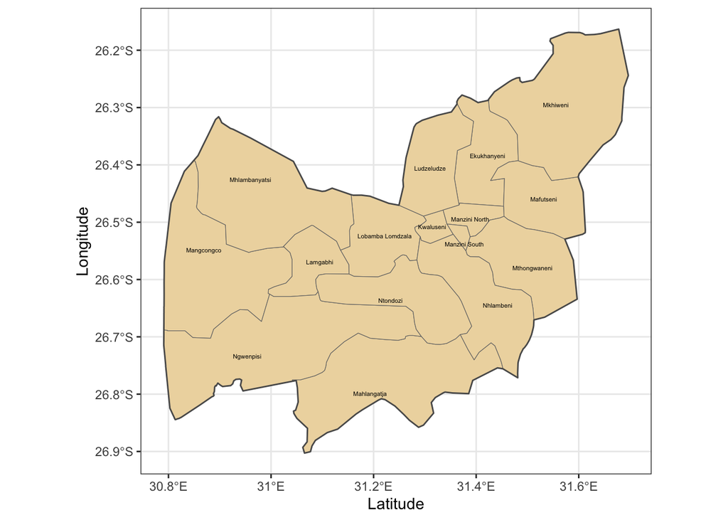

## 2.2 Arranging Plots

Finally, I put a few plots together on the same axes. The idea here was to identify a couple of different areas on the country map and then to zoom in on those areas of interest.

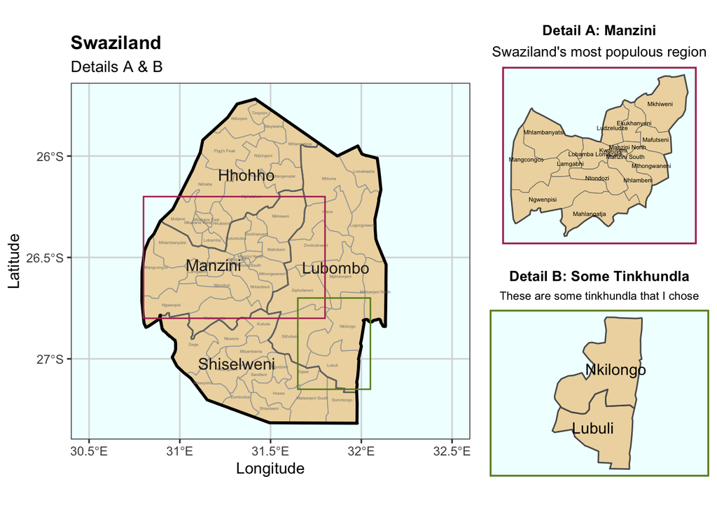

This is really a nice plot. I especially had fun fiddling with the different axis elements (i.e., `panel.border`, `panel.background`, `axis.ticks`, etc.) to make the plot more clear. The one issue is that the labels in the Manzini plot overlap, making it a little hard to read.